# Concrete_Strength_Project6_AjitGaniger

#### Lets analyze strength column with other column to understand the relationship

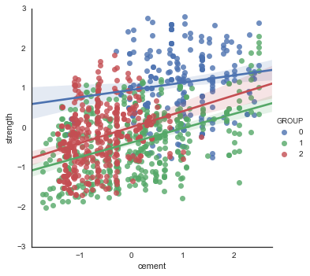

```python
# strength Vs cement

var = 'cement'

with sns.axes_style("white"):
    plot = sns.lmplot(var,target,data=data_df_clust,hue='GROUP')
plot.set(ylim = (-3,3))
```

What we infer from the graph is

- there is very good relationship between group of data point falling in group 1 and 2
- however data point belonging to group 0 of cement column are weak in predicting the strentgh
- key point is, more the horizontal like, more weak in predicting the target strength

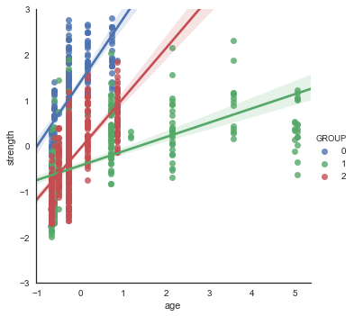

```python
# strength Vs age

var = 'age'

with sns.axes_style("white"):
    plot = sns.lmplot(var,target,data=data_df_clust,hue='GROUP')
plot.set(ylim = (-3,3))
```

What we infer from the graph is

- In this case all the group 0,1,2 data of age are good in prediting the strength
- key point is, more the horizontal like, more weak in predicting the target strength

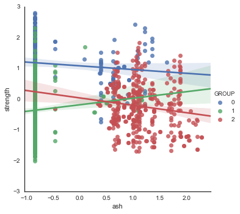

```python
# strength Vs ash

var = 'ash'

with sns.axes_style("white"):
    plot = sns.lmplot(var,target,data=data_df_clust,hue='GROUP')
plot.set(ylim = (-3,3))
```

- since all the lines are horizontal none of the groups of ash are helping in predicting the target strength

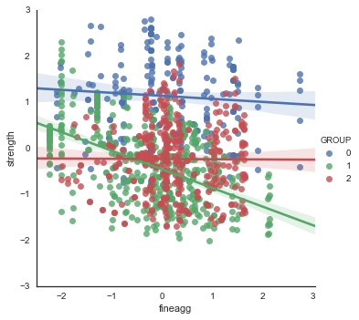

```python
# strength Vs fineagg

var = 'fineagg'

with sns.axes_style("white"):
    plot = sns.lmplot(var,target,data=data_df_clust,hue='GROUP')
plot.set(ylim = (-3,3))
```

- from the graph we see that data belongs to group 1 of fineagg column are good in predicting target but not other 2 group data

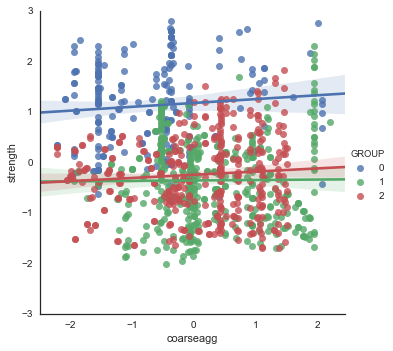

```python
# strength Vs coarseagg

var = 'coarseagg'

with sns.axes_style("white"):
    plot = sns.lmplot(var,target,data=data_df_clust,hue='GROUP')
plot.set(ylim = (-3,3))
```

- none of the group are good in predicting target ( all the lines are horizontal)

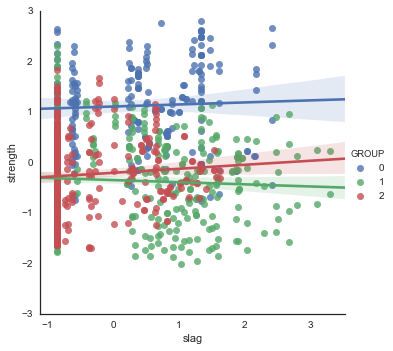

```python
# strength Vs slag

var = 'slag'

with sns.axes_style("white"):
    plot = sns.lmplot(var,target,data=data_df_clust,hue='GROUP')
plot.set(ylim = (-3,3))
```

- Same case with slag feature, all groups are weak predictor of target column

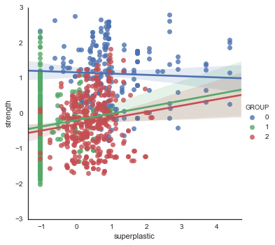

```python
# strength Vs superplastic

var = 'superplastic'

with sns.axes_style("white"):
    plot = sns.lmplot(var,target,data=data_df_clust,hue='GROUP')
plot.set(ylim = (-3,3))
```

- form the graph we can infer tht group 1 and 2 data of supersplastic are good predictor of target column

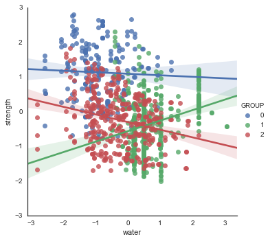

```python
# strength Vs water

var = 'water'

with sns.axes_style("white"):
    plot = sns.lmplot(var,target,data=data_df_clust,hue='GROUP')
plot.set(ylim = (-3,3))
```

- in this case only gropu 1 and 2 looks to be good predictors of target